# ECON 5181 Assignment 2

#### 9. Now, experiment with a few other algorithms -- random forest and neural network -- to predict credit default. Examine the confusion matrix and accuracy rates. Report the test error (i.e., misclassification rate) for all models, including logistic regression and regularized logistic regression, in a summary table. Plot the ROC curve for all models on one single graph. Which algorithm wins in predicting default?

You need to split your sample into train (80%) and test (20%) for this exercise.

```
confusion matrix:
 [[127  15]
 [ 32  26]]
accuracy rate:  0.765
sensitivity:  0.4482758620689655
specificity:  0.6341463414634146
```

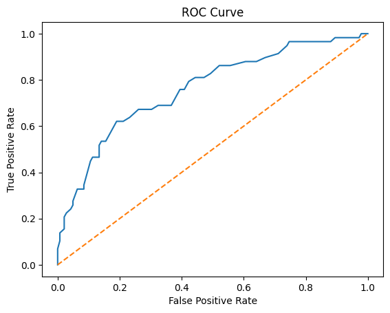

```python
# random forest
from sklearn.ensemble import RandomForestClassifier
model = RandomForestClassifier()
model.fit(X_train, y_train)
y_pred = model.predict(X_test)
print("confusion matrix: \n", confusion_matrix(y_test, y_pred))
print("accuracy rate: ",accuracy_score(y_test, y_pred))
print("sensitivity: ", recall_score(y_test, y_pred))
print("specificity: ", precision_score(y_test, y_pred))
fpr1, tpr1, thresholds1 = roc_curve(y_test, model.predict_proba(X_test)[:, 1])
plt.plot(fpr1, tpr1, label='random forest')
plt.plot([0, 1], [0, 1], linestyle='--')
plt.xlabel('False Positive Rate')
plt.ylabel('True Positive Rate')
plt.title('ROC Curve')
```

```
confusion matrix:
 [[113  29]
 [ 26  32]]
accuracy rate:  0.725
sensitivity:  0.5517241379310345
specificity:  0.5245901639344263
```

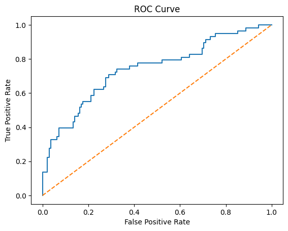

```python
# neural network
from sklearn.neural_network import MLPClassifier
model = MLPClassifier()
model.fit(X_train, y_train)
y_pred = model.predict(X_test)
print("confusion matrix: \n", confusion_matrix(y_test, y_pred))
print("accuracy rate: ",accuracy_score(y_test, y_pred))
print("sensitivity: ", recall_score(y_test, y_pred))
print("specificity: ", precision_score(y_test, y_pred))
fpr2, tpr2, thresholds2 = roc_curve(y_test, model.predict_proba(X_test)[:, 1])
plt.plot(fpr2, tpr2, label='neural network')
plt.plot([0, 1], [0, 1], linestyle='--')
plt.xlabel('False Positive Rate')
plt.ylabel('True Positive Rate')
plt.title('ROC Curve')
```

```
confusion matrix:
 [[118  24]
 [ 26  32]]
accuracy rate:  0.75
sensitivity:  0.5517241379310345
specificity:  0.5714285714285714
```

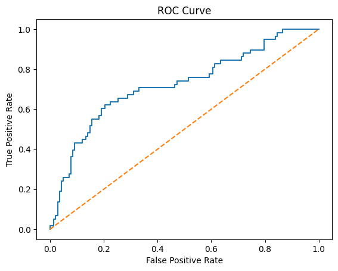

```python
# Logistic regression
model = LogisticRegression()
model.fit(X_train, y_train)
y_pred = model.predict(X_test)
print("confusion matrix: \n", confusion_matrix(y_test, y_pred))
print("accuracy rate: ",accuracy_score(y_test, y_pred))
print("sensitivity: ", recall_score(y_test, y_pred))
print("specificity: ", precision_score(y_test, y_pred))
fpr3, tpr3, thresholds3 = roc_curve(y_test, model.predict_proba(X_test)[:, 1])
plt.plot(fpr3, tpr3, label='logistic regression')
plt.plot([0, 1], [0, 1], linestyle='--')
plt.xlabel('False Positive Rate')
plt.ylabel('True Positive Rate')
plt.title('ROC Curve')
```

```
confusion matrix:
 [[121  21]
 [ 25  33]]
accuracy rate:  0.77
sensitivity:  0.5689655172413793
specificity:  0.6111111111111112
```

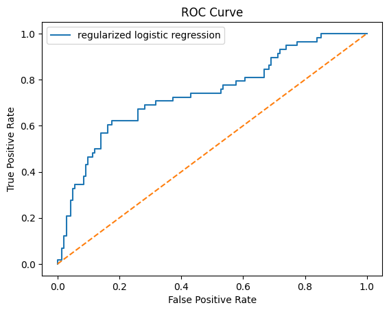

```python
# Regularized logistic regression
model = LogisticRegression(penalty='l1', solver='liblinear', C=grid_search.best_params_['C'])
model.fit(X_train, y_train)
y_pred = model.predict(X_test)
print("confusion matrix: \n", confusion_matrix(y_test, y_pred))
print("accuracy rate: ",accuracy_score(y_test, y_pred))
print("sensitivity: ", recall_score(y_test, y_pred))
print("specificity: ", precision_score(y_test, y_pred))
fpr4, tpr4, thresholds4 = roc_curve(y_test, model.predict_proba(X_test)[:, 1])
plt.plot(fpr4, tpr4, label='regularized logistic regression')
plt.plot([0, 1], [0, 1], linestyle='--')
plt.xlabel('False Positive Rate')
plt.ylabel('True Positive Rate')
plt.title('ROC Curve')
plt.legend()
```

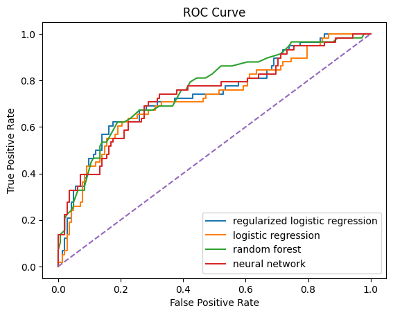

```python
# Summary
plt.plot(fpr4, tpr4, label='regularized logistic regression')
plt.plot(fpr3, tpr3, label='logistic regression')
plt.plot(fpr1, tpr1, label='random forest')
plt.plot(fpr2, tpr2, label='neural network')
plt.plot([0, 1], [0, 1], linestyle='--')
plt.xlabel('False Positive Rate')
plt.ylabel('True Positive Rate')
plt.title('ROC Curve')
plt.legend()
```

[output not shown]

With some tuning, regularized logistic regression is the best model in terms of accuracy rate.

### Congrats, you are done!

Before you quit the document, here is one thing to ponder. Do loan officers actually make their decision based on these prediction algorithms? If not, how do they fare compared to the algorithms we trained using retrospective data?

These turn out to be a difficult and deep questions (let alone the ethical and philosophical issues), but also extremely worthwhile to think about in the age of automation. A few economists teamed up with computer scientists and provided us with some interesting food for thought: [Human Decisions and Machine Predictions in the context of criminal justice](https://doi.org/10.1093/qje/qjx032)

Reference: Jon Kleinberg, Himabindu Lakkaraju, Jure Leskovec, Jens Ludwig, Sendhil Mullainathan, *Human Decisions and Machine Predictions*, The Quarterly Journal of Economics, Volume 133, Issue 1, February 2018, Pages 237–293

```python
# convert to html
!jupyter nbconvert --to html assignment_2.ipynb
```

```
[NbConvertApp] Converting notebook assignment_2.ipynb to html
[NbConvertApp] Writing 1850743 bytes to assignment_2.html
```